```r
set.seed(271)
```

# Brownian motion

First let’s start by simulating Brownian motion, as the scaling limit of simple random walks.

First let’s simulate a simple random walk.

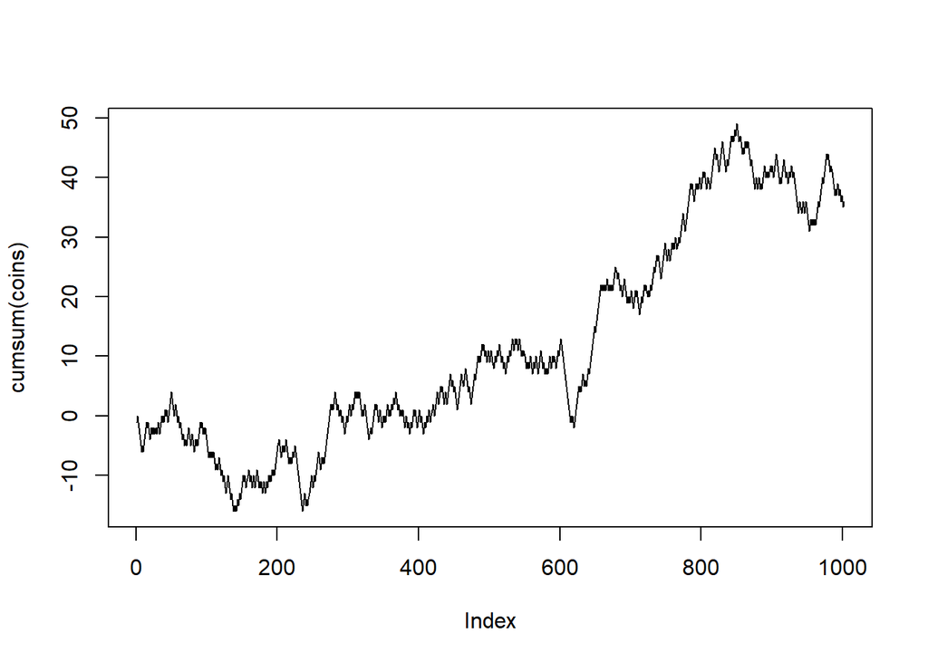

```r
n <- 1002
coins <- sample(c(-1,1), n, replace=TRUE)
plot(cumsum(coins), type='l')
```

Let’s look at how this rescales to look like Brownian motion.

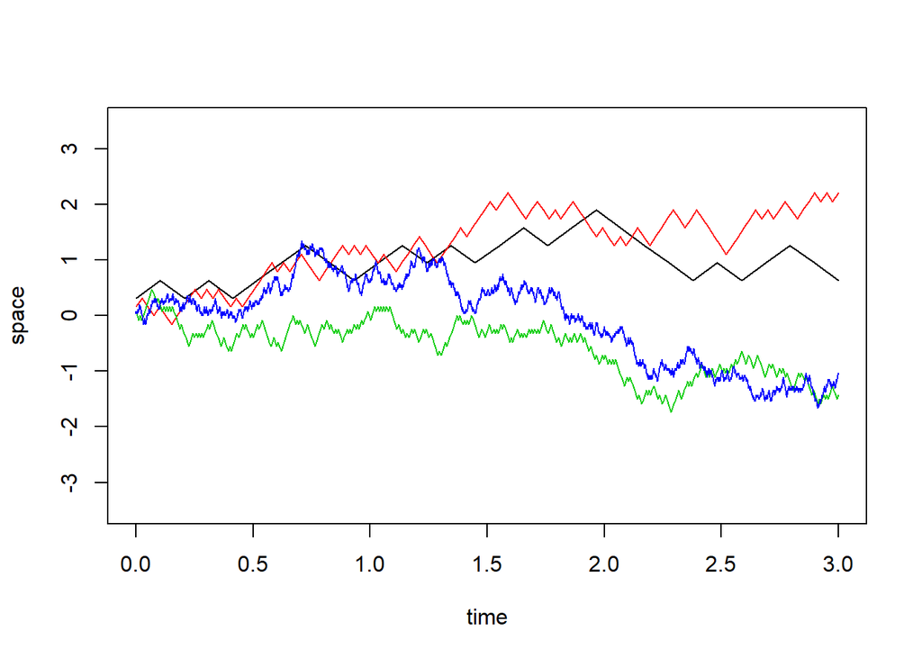

```r
srw_bm <- function (tmax, N) {
    coins <- sample(c(-1,1), floor(tmax * N), replace=TRUE)
    return(cumsum(coins) / sqrt(N))
}
tmax <- 3
Nvals <- c(10, 40, 160, 640)
for (N in Nvals) {
    srw <- srw_bm(tmax, N=N)
    tvals <- seq(0, tmax, length.out=length(srw))
    if (N == Nvals[1]) {
        plot(tvals, srw, type='l', xlab='time', ylab='space', ylim=c(-2*sqrt(3),2*sqrt(3)))
    } else {
        lines(tvals, srw, col=match(N, Nvals))
    }
}
```

Let’s test this is working right. If this is a good approximation to Brownian motion, the distribution at time 3 should be Normal(0,$\sigma^2=3$).

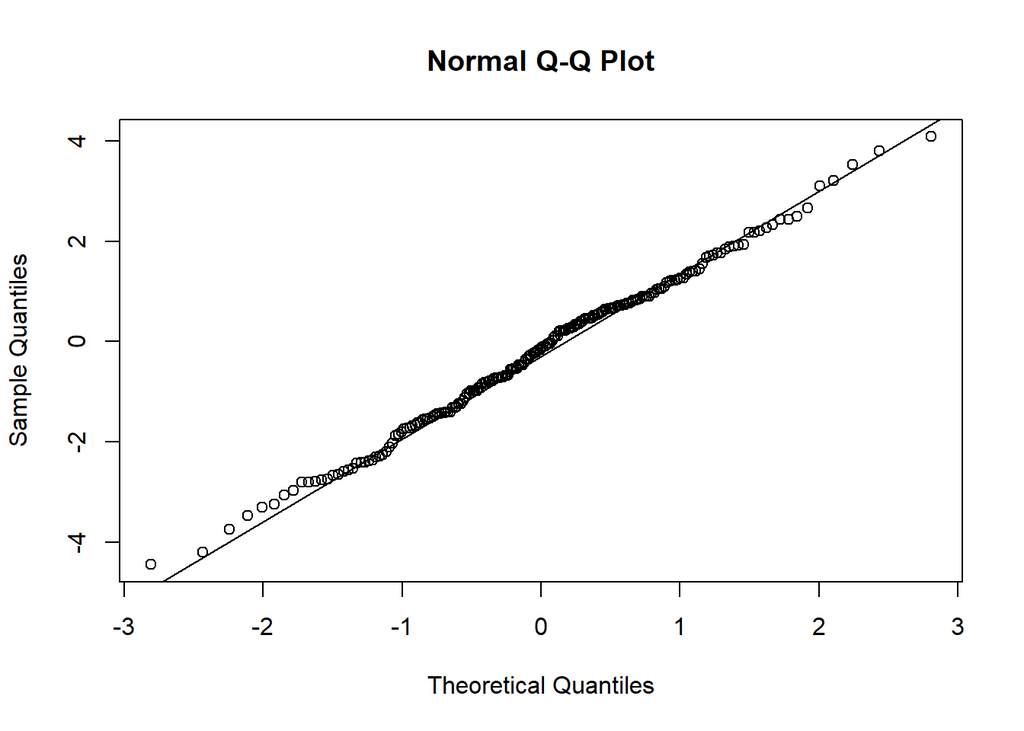

```r
srw_reps <- replicate(200, srw_bm(3, 10000))
qqnorm(srw_reps[nrow(srw_reps),])
qqline(srw_reps[nrow(srw_reps),])
```

That looks about right. And the sample variance is 2.5270133, which is close to 3.

## Function space

We will now simulate Brownian motion on $[0,1]$ using the Levy construction, using the integrals of the Haar basis and the isometry of $L^2([0,1])$.

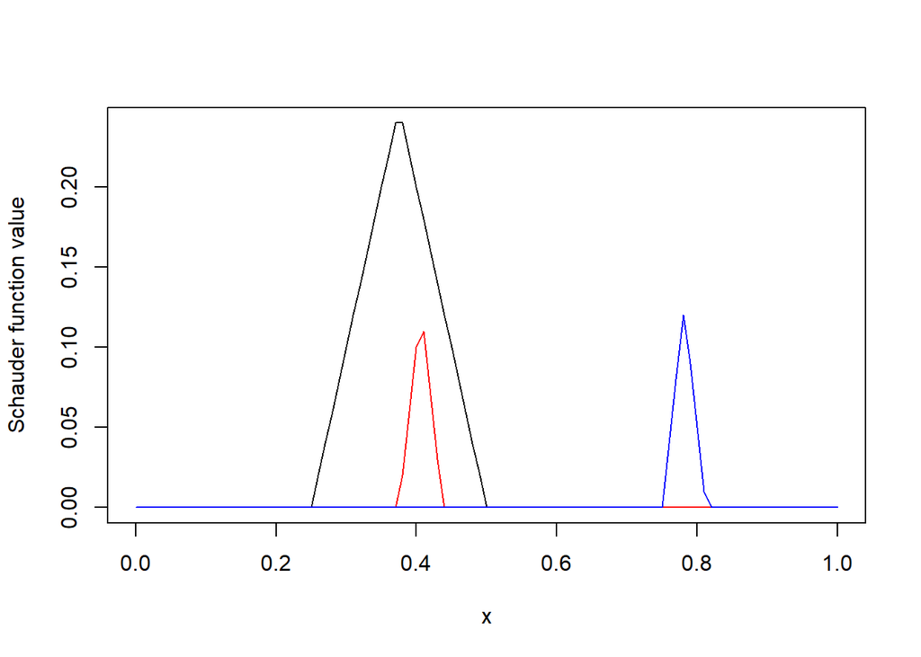

```r
haar_integral <- function (x, n, k) {
    a <- 2 * k / 2^n
    b <- (2 * k  + 1)/ 2^n
    c <- (2 * k  + 2)/ 2^n
    2^((n-1)/2) * ifelse(x < a, 0,
                         ifelse(x < b, x - a,
                                ifelse(x < c, c - x, 0)))
}

curve(haar_integral(x, n=3, k=1), from=0, to=1, ylab='Schauder function value')
curve(haar_integral(x, n=5, k=6), from=0, to=1, add=TRUE, col='red')
curve(haar_integral(x, n=5, k=12), from=0, to=1, add=TRUE, col='blue')
```

Ok, that’s our (integrated) basis functions. Now we need to add them up with independent Gaussian coefficients.

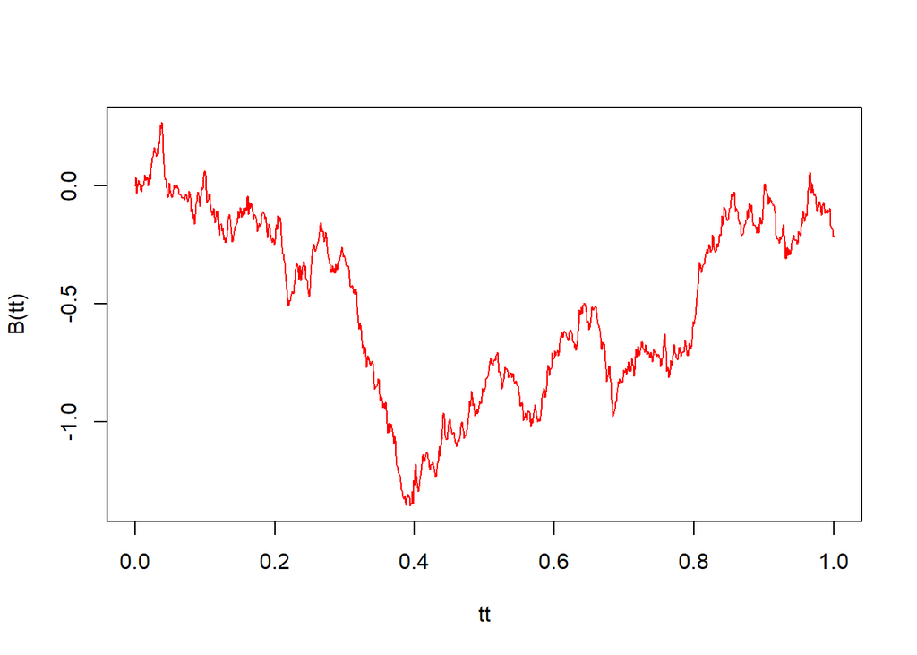

```r
haar_bm <- function (nmax, Z, B0 = 0, bridge=FALSE) {
  ## this function returns the nmax partial sum
  ## of B_t, as a function of t in [0,1]
    if (bridge) {
        nk <- data.frame(n=1, k=0) # if bridge, omit first term
    } else {
        nk <- data.frame(n=c(0,1), k=c(0,0))
    }
    # indices to sum over
    for (nn in seq(2, nmax)) {
        nk <- rbind(nk, data.frame(n=nn, k=0:(2^(nn-1)-1)))
    }
    # get list of integrated basis functions (as functions of upper limit of integration)
    fns <- lapply(1:nrow(nk), function (j)
                  function (x) haar_integral(x, n=nk$n[j], k=nk$k[j]))
    # the random coefficients
    if (missing(Z)) {
        Z <- rnorm(nrow(nk), 0, sd=1)
    }
    return(function (x) {
        Z %*% do.call(rbind, lapply(fns, function (f) f(x)))
    })
}

B <- haar_bm(10)
tt <- seq(0,1,length.out=1e3)
plot(tt, B(tt), col='red', type = 'l')
```

Let’s see how we constructed $B$ from successively rougher functions.

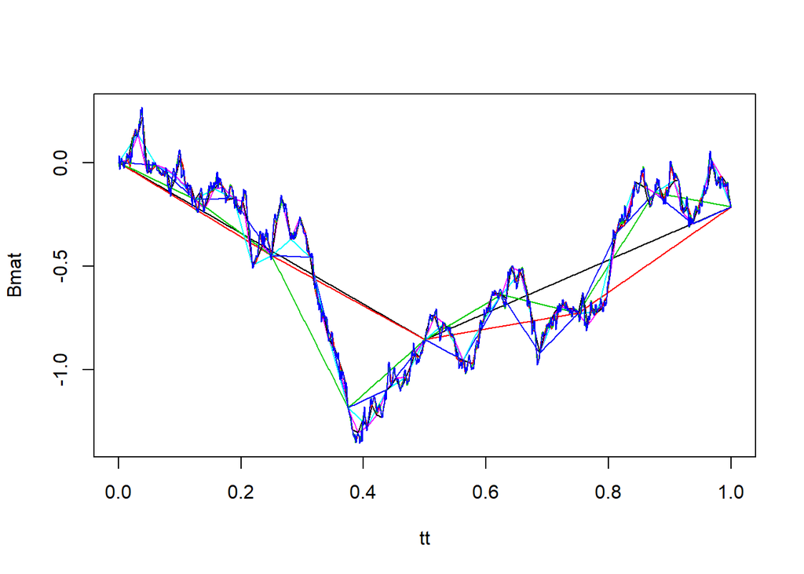

```r
# get collection of independent iid N(0,1)
Z <- with(environment(B), Z)
# repeat n 2^(n-1) times
n_index <- rep(0:10, c(1, 2^(0:9)))
# generate list of haar bm with nmax=10
Blist <- lapply(1:10, function (n) {
                    haar_bm(10, Z=ifelse(n_index <= n, Z, 0)) } )
Bmat <- sapply(Blist, function (fB) fB(tt))
matplot(tt, Bmat, type='l', lty=1)
```

# Gaussian process regression

Now let’s suppose we have noisy measurements of $B_0 + B_t$, where $B_0 \sim \operatorname{Normal}(0, \eta^2)$, at some time points: for $t_1 < \cdots < t_n$ let $X_i = B_0 + B_{t_i} + W_i$, for iid $\operatorname{Normal}(0, \sigma^2)$ random variables $W_i$. Now we want to *sample* from the distribution on $B_0 + B_t$ *given* $(X_1, \ldots, X_n)$. This is equivalent to sampling from the distribution on $(B_0,Z)$ given $(X_1, \ldots, X_n)$, then using the random coefficients to obtain $B_t$.

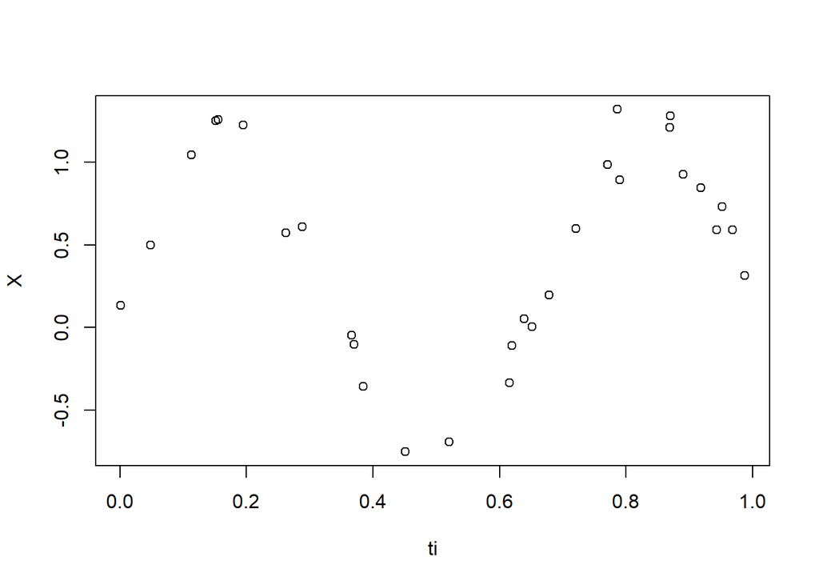

```r
n <- 30 # number of data points
sigma <- 0.1 # residual sd
eta <- 0.5 # starting point sd
ti <- sort(runif(n))
B0 <- rnorm(1, sd=eta)
X <- B0 + sin(ti*3*pi) + rnorm(n, sd=sigma)
plot(ti, X)
```

We will want to

1. evaluate the conditional *mean* at a bunch of time points, to get a smooth curve going near our data, and
2. sample from the conditional distribution to get an idea of uncertainty.

To do this, we need the (a) covariance matrix of $X$, and (b) the covariance matrix of $(B_0, Z)$, and (c) the covariance matrix of $X$ with $(B_0, Z)$. Math on the board gives us that $\operatorname{cov}[X_i, B_0] = \eta^2$, that $\operatorname{cov}[X_i, X_j] = \eta^2 + \min(t_i, t_j) + \delta_{ij} \sigma^2$, and that $\operatorname{cov}[X_i, Z_{m\ell}] = H_{m,\ell}(t_i)$, where $H_{m,\ell}(t) = \int_0^t h_{m,\ell}(s)\,ds$ is the corresponding integrated basis function.

```r
# construct covX
covX <- diag(n) * sigma^2
for (i in 1:n) {
    for (j in 1:n) {
        covX[i,j] <- covX[i,j] + min(ti[i], ti[j]) + eta^2
    }
}
nmax <- with(environment(B), nmax)
# get basis functions from B to build covXZ
basis_fns <- with(environment(B), fns)
covXZ <- matrix(NA, nrow=n, ncol=length(basis_fns)+1)
for (i in 1:n) {
    for (j in 1:length(basis_fns)) {
        covXZ[i,j+1] <- basis_fns[[j]](ti[i])
    }
}
covXZ[,1] <- eta^2
# construct covZZ
covZZ <- diag(length(basis_fns)+1)
covZZ[1,1] <- eta^2
```

The mean will be $\Sigma_{ZX} \Sigma_{XX}^{-1} X$ and the covariance matrix will be $\Sigma_{ZZ} - \Sigma_{ZX} \Sigma_{XX}^{-1} \Sigma_{XZ}$.

```r
mean_mat <- t(covXZ) %*% solve(covX)
cov_mat <- covZZ - t(covXZ) %*% solve(covX, covXZ)
chol_cov_mat <- chol(cov_mat) # for sampling

mean_B <- function (x) {
  ## this function returns a list with two elements,
  ## the first being the conditional mean path,
  ## the second being the conditional mean B0
    mean_Z <- as.vector(mean_mat %*% x)
    B0_mean <- mean_Z[1]
    return( list(haar_bm(nmax, mean_Z[-1]), B0_mean) )
}

# these will be *deviations* from the mean
conditional_B <- function (x) {
    Z <- as.vector(chol_cov_mat %*% rnorm(length(basis_fns)+1))
    B0 <- Z[1]
    dB <- haar_bm(nmax, Z[-1])
    return( list(dB, B0) )
}

mB <- mean_B(X)[[1]]
B0_mean <- mean_B(X)[[2]]
cB <- replicate(100, conditional_B(X))
B0 <- as.numeric(cB[2,])
```

Here we plot the conditional mean (in red) and a bunch of samples (in black).

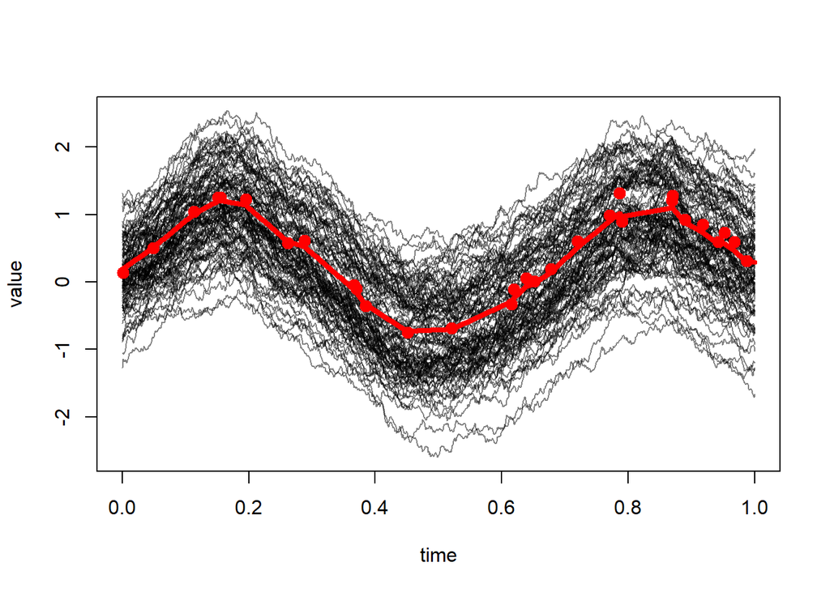

```r
# conditional mean points
mBvals <- B0_mean + as.vector(mB(tt))
# samples from conditional distribution
cBmat <- sapply(cB[1,], function (f) f(tt))
cBmat <- rep(B0, each=nrow(cBmat) ) + cBmat
matplot(tt,mBvals + cBmat, type='l', col=adjustcolor('black', 0.5),
        xlab='time', ylab='value', lty=1)
points(ti, X, pch=20, col='red', cex=2)
lines(tt, mBvals, col='red', lwd=4)
```